# 🔎 Project Information

#### 📌 Project Team: PTID-CDS-DEC-25-3482

#### 📌 Project Name: PRCP-1002 — Handwritten Digits Recognition

## 📌 Problem Statement

Handwritten digit recognition is a fundamental problem in the field of computer vision and machine learning.  
The objective of this project is to build a system that can accurately classify a given image of a handwritten digit into one of the **10 classes representing digits from 0 to 9**.

This project uses the **MNIST dataset**, which is a standard benchmark dataset widely used for evaluating classification algorithms. The dataset consists of grayscale images of handwritten digits and provides a strong foundation to experiment with different machine learning and deep learning techniques.

## 🎯 Project Objectives

The main objectives of this project are:

- 📊 To perform a **complete exploratory data analysis (EDA)** on the MNIST dataset
- 🧠 To build classification models capable of recognizing handwritten digits
- 🔍 To **compare multiple models** and analyze their performance
- ✅ To identify the **best-performing model suitable for production use**

## 📂 Dataset Description

The dataset used in this project is the **MNIST (Modified National Institute of Standards and Technology) dataset**.

### 🔎 Dataset Characteristics:

- The dataset contains **tens of thousands of grayscale images**
- Each image represents a **single handwritten digit**
- Image dimensions are **28 × 28 pixels**
- Pixel values range from **0 to 255**
- The output consists of **10 classes**, representing digits from **0 to 9**

The dataset is well-structured and labeled, making it suitable for both traditional machine learning algorithms and deep learning-based approaches.

## 🛠️ Skills and Techniques Covered

Through this project, the following skills and techniques are practiced:

- 🖼️ Computer vision fundamentals
- ⚙️ Image preprocessing and normalization
- 📈 Classification techniques such as:
  - Logistic Regression
  - K-Nearest Neighbors (KNN)
  - Support Vector Machines (SVM)
  - Artificial Neural Networks (ANN)
  - Convolutional Neural Networks (CNN)
- 📊 Model evaluation and performance comparison

## 📝 Note

All the above tasks are implemented within a **single Jupyter Notebook**, as required.  
The complete workflow is documented using code cells, visualizations, and explanatory markdown cells.

```python
# Numerical computation
import numpy as np

# Data handling and analysis
import pandas as pd

# Data visualization
import matplotlib.pyplot as plt
import seaborn as sns

# To ignore unnecessary warning messages
import warnings
warnings.filterwarnings('ignore')
```

```python
from tensorflow.keras.datasets import mnist # Load datasets
(x_train, y_train), (x_test, y_test) = mnist.load_data()
```

```
Downloading data from https://storage.googleapis.com/tensorflow/tf-keras-datasets/mnist.npz
11490434/11490434 ━━━━━━━━━━━━━━━━━━━━ 1s 0us/step
```

```python
df=mnist.load_data()
```

```python
df
```

[output not shown]

[output cut: 45 more lines]

[output not shown]

```python
x_train
```

[output not shown]

```python
print(f"Training data shape: {x_train.shape}")
print(f"Test data shape: {x_test.shape}")
print(f"Training labels shape: {y_train.shape}")
```

```
Training data shape: (60000, 28, 28)
Test data shape: (10000, 28, 28)
Training labels shape: (60000,)
```

```python
# EDA:- Exploratory Data Analysis
```

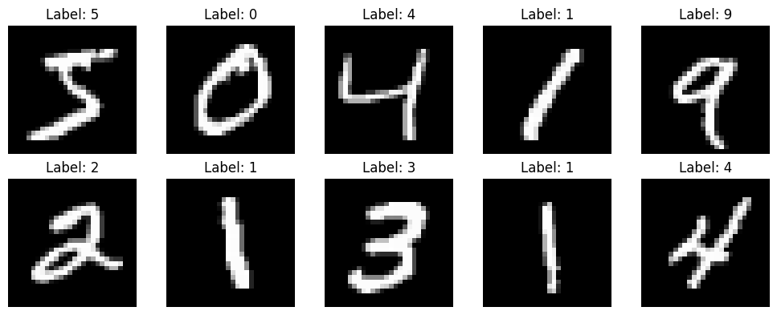

```python
plt.figure(figsize=(10, 4))
for i in range(10):
    plt.subplot(2, 5, i+1)
    plt.imshow(x_train[i], cmap='gray')
    plt.title(f"Label: {y_train[i]}")
    plt.axis('off')
plt.tight_layout()
plt.show()
```

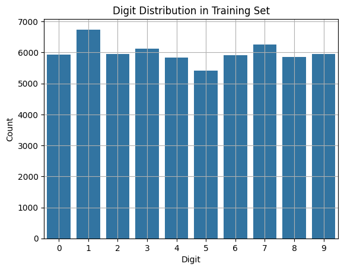

```python
# Distribution of Classes in Training Data
sns.countplot(x=pd.Series(y_train))
plt.title("Digit Distribution in Training Set")
plt.xlabel("Digit")
plt.ylabel("Count")
plt.grid(True)
plt.show()
```

```python
# Pixel Value Range and Statistics
print("Pixel value statistics for training data:")
print(f"Min value: {x_train.min()}")
print(f"Max value: {x_train.max()}")
print(f"Mean pixel value: {x_train.mean():.2f}")
print(f"Std dev of pixel values: {x_train.std():.2f}")
```

```
Pixel value statistics for training data:
Min value: 0
Max value: 255
Mean pixel value: 33.32
Std dev of pixel values: 78.57
```

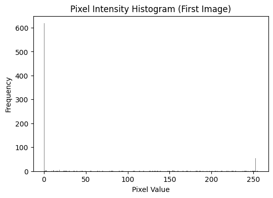

```python
# Histogram of Pixel Values for a Sample Image
plt.figure(figsize=(6, 4))
plt.hist(x_train[0].ravel(), bins=256, range=(0, 255), color='gray')
plt.title("Pixel Intensity Histogram (First Image)")
plt.xlabel("Pixel Value")
plt.ylabel("Frequency")
plt.show()
```

```python
# Check for Missing or NaN Values
print("Checking for missing values...")
print("x_train missing:", np.isnan(x_train).sum())
print("y_train missing:", np.isnan(y_train).sum())
print("x_test missing:", np.isnan(x_test).sum())
print("y_test missing:", np.isnan(y_test).sum())
```

```
Checking for missing values...
x_train missing: 0
y_train missing: 0
x_test missing: 0
y_test missing: 0
```

```python
# Check Shape of One Image and Its Type
print("Shape of one image:", x_train[0].shape)
print("Data type of image:", type(x_train[0]))
```

```
Shape of one image: (28, 28)
Data type of image: <class 'numpy.ndarray'>
```

```python
# Reshape x_train to (60000, 784) — each row is an image, each column is a pixel
x_flat = x_train.reshape(x_train.shape[0], -1)
```

```python
df_pixels = pd.DataFrame(x_flat)
```

```python
correlation_matrix = df_pixels.corr()
```

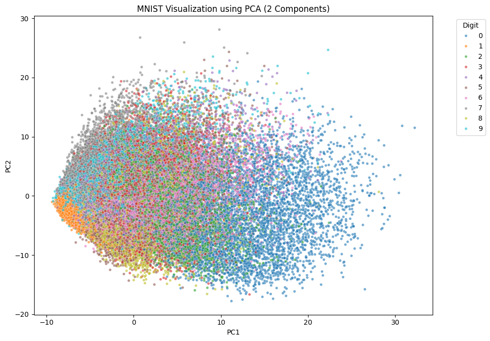

```python
from tensorflow.keras.datasets import mnist
from sklearn.decomposition import PCA
from sklearn.preprocessing import StandardScaler

# Load the data
(x_train, y_train), (_, _) = mnist.load_data()

# Flatten 28x28 images to 1D vectors (784 features)
x_flat = x_train.reshape(x_train.shape[0], -1)

# Optional: Normalize pixel values to [0, 1]
x_flat = x_flat / 255.0

# Standardize data (important for PCA)
scaler = StandardScaler()
x_scaled = scaler.fit_transform(x_flat)

# Apply PCA to reduce to 2 components
pca = PCA(n_components=2)
x_pca = pca.fit_transform(x_scaled)

# Convert to DataFrame for plotting
df_pca = pd.DataFrame(data=x_pca, columns=['PC1', 'PC2'])
df_pca['label'] = y_train

# Plot the PCA result
plt.figure(figsize=(10, 7))
sns.scatterplot(x='PC1', y='PC2', hue='label', data=df_pca, palette='tab10', alpha=0.6, s=15)
plt.title("MNIST Visualization using PCA (2 Components)")
plt.legend(title='Digit', bbox_to_anchor=(1.05, 1), loc='upper left')
plt.tight_layout()
plt.show()
```

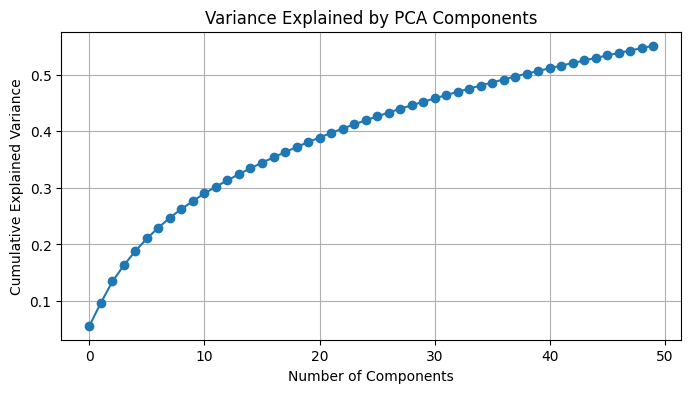

```python
# Check how much variance is retained
pca_full = PCA().fit(x_scaled)
plt.figure(figsize=(8, 4))
plt.plot(np.cumsum(pca_full.explained_variance_ratio_[:50]), marker='o')
plt.xlabel('Number of Components')
plt.ylabel('Cumulative Explained Variance')
plt.title('Variance Explained by PCA Components')
plt.grid(True)
plt.show()
```

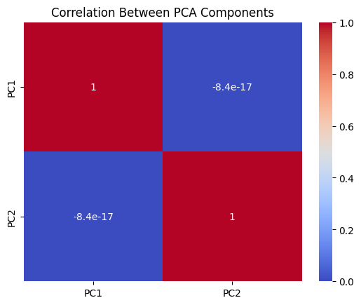

```python
df_pca_corr = df_pca[['PC1', 'PC2']].corr()
sns.heatmap(df_pca_corr, annot=True, cmap='coolwarm')
plt.title("Correlation Between PCA Components")
plt.show()
```

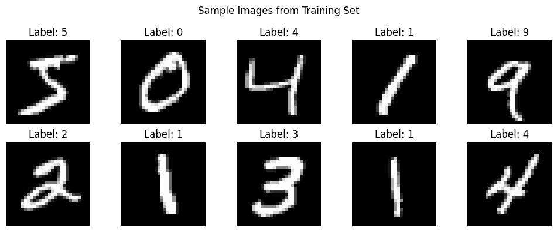

```python
plt.figure(figsize=(10, 4))
for i in range(10):
    plt.subplot(2, 5, i+1)
    plt.imshow(x_train[i], cmap='gray')
    plt.title(f"Label: {y_train[i]}")
    plt.axis('off')
plt.suptitle("Sample Images from Training Set")
plt.tight_layout()
plt.show()
```

```python
# Model Selection
```

```python
from sklearn.datasets import fetch_openml
from sklearn.model_selection import train_test_split
from sklearn.metrics import accuracy_score, precision_score, f1_score
from sklearn.linear_model import LogisticRegression
from sklearn.neighbors import KNeighborsClassifier
from sklearn.ensemble import RandomForestClassifier, GradientBoostingClassifier
from sklearn.svm import SVC
from sklearn.neural_network import MLPClassifier
from sklearn.preprocessing import StandardScaler
```

```python
a = accuracy_score # evaluation metrics for classification model
p = precision_score
f = f1_score
def evaluate_model(true, predicted):
    accuracy_score = a(true, predicted) # evaluation metrics for classification model
    precision_score = p(true, predicted)
    f1_score_score = f(true, predicted)
    return accuracy_score,precision_score,f1_score_score # evaluation metrics for classification model
```

```python
# Original shape: (n_samples, 28, 28)
# Flatten to: (n_samples, 784)
X_train = x_train.reshape(x_train.shape[0], -1)
X_test = x_test.reshape(x_test.shape[0], -1)

# Scale the flattened data
scaler = StandardScaler()
X_train_scaled = scaler.fit_transform(X_train)
X_test_scaled = scaler.transform(X_test)
```

```python
# Flatten the 28x28 images to 784-dimension vectors
X_train_flat = X_train.reshape(X_train.shape[0], -1)
X_test_flat = X_test.reshape(X_test.shape[0], -1)

# Normalize pixel values [0, 1]
X_train_flat = X_train_flat / 255.0
X_test_flat = X_test_flat / 255.0

# Optional: Reduce to smaller set to prevent MemoryError
X = np.concatenate((X_train_flat, X_test_flat), axis=0)
y = np.concatenate((y_train, y_test), axis=0)

X_sub, _, y_sub, _ = train_test_split(X, y, train_size=2000, stratify=y, random_state=42)  # Use only 2000 samples

# Split into train/test
X_train, X_test, y_train, y_test = train_test_split(X_sub, y_sub, test_size=0.25, stratify=y_sub, random_state=42)

# Standardize
scaler = StandardScaler()
X_train_scaled = scaler.fit_transform(X_train)
X_test_scaled = scaler.transform(X_test)
```

```python
# Define models
models = {
    "Logistic Regression": LogisticRegression(max_iter=1000),
    "K-Nearest Neighbors (KNN)": KNeighborsClassifier(),
    "Random Forest Classifier": RandomForestClassifier(),
    "Support Vector Machine": SVC(),
    "Gradient Boosting Classifier": GradientBoostingClassifier(),
    "MLPClassifier": MLPClassifier(max_iter=500)
}
```

```python
# Evaluate models
model_list=[]
accuracy_score_list =[]
for i in range(len(list(models))):
    model = list(models.values())[i]
    # Use scaled data where required
    if model in ["Logistic Regression", "Support Vector Machine", "MLPClassifier"]:
        model.fit(X_train_scaled, y_train)
        y_pred_train = model.predict(X_train_scaled)
        y_pred_test = model.predict(X_test_scaled)

    else:
        model.fit(X_train, y_train)
        y_pred_train = model.predict(X_train)
        y_pred_test = model.predict(X_test)

    model_list.append(list(models.keys())[i])



# Training metrics
    train_acc = accuracy_score(y_train, y_pred_train)
    train_prec = precision_score(y_train, y_pred_train, average='macro', zero_division=0)
    train_f1 = f1_score(y_train, y_pred_train, average='macro')

    # Test metrics
    test_acc = accuracy_score(y_test, y_pred_test)
    test_prec = precision_score(y_test, y_pred_test, average='macro', zero_division=0)
    test_f1 = f1_score(y_test, y_pred_test, average='macro')

    # Print formatted result
    print(f"\n{model}")
    print("Model Performance for Training set")
    print(f"- accuracy_score: {train_acc:.4f}")
    print(f"- precision_score: {train_prec:.4f}")
    print(f"- f1_score_score: {train_f1:.4f}")
    print("----------------------------------")
    print("Model performance for Test set")
    print(f"- accuracy_score: {test_acc:.4f}")
    print(f"- precision_score: {test_prec:.4f}")
    print(f"- f1_score_score: {test_f1:.4f}")
    print("===================================")

    accuracy_score_list.append(test_acc) # evaluation metrics for classification model
```

```
LogisticRegression(max_iter=1000)
Model Performance for Training set
- accuracy_score: 0.9993
- precision_score: 0.9994
- f1_score_score: 0.9993
----------------------------------
Model performance for Test set
- accuracy_score: 0.8660
- precision_score: 0.8675
- f1_score_score: 0.8626
===================================

KNeighborsClassifier()
Model Performance for Training set
- accuracy_score: 0.9393
- precision_score: 0.9430
- f1_score_score: 0.9393
----------------------------------
Model performance for Test set
- accuracy_score: 0.9040
- precision_score: 0.9065
- f1_score_score: 0.9027
===================================

RandomForestClassifier()
Model Performance for Training set
- accuracy_score: 1.0000
- precision_score: 1.0000
- f1_score_score: 1.0000
----------------------------------
Model performance for Test set
- accuracy_score: 0.9120
- precision_score: 0.9125
- f1_score_score: 0.9103
===================================

SVC()
Model Performance for Training set
- accuracy_score: 0.9833
- precision_score: 0.9836
```

[output cut: 16 more lines]

```
- precision_score: 0.8913
- f1_score_score: 0.8894
===================================

MLPClassifier(max_iter=500)
Model Performance for Training set
- accuracy_score: 1.0000
- precision_score: 1.0000
- f1_score_score: 1.0000
----------------------------------
Model performance for Test set
- accuracy_score: 0.9080
- precision_score: 0.9081
- f1_score_score: 0.9059
===================================
```

```python
accuracy_score_list
```

```
[0.866, 0.904, 0.912, 0.924, 0.892, 0.908]
```

```python
model_list
```

```
['Logistic Regression',
 'K-Nearest Neighbors (KNN)',
 'Random Forest Classifier',
 'Support Vector Machine',
 'Gradient Boosting Classifier',
 'MLPClassifier']
```

```python
score = pd.DataFrame(list(zip(model_list, accuracy_score_list)),
                     columns=['Model Name', 'Accuracy_score']).sort_values(by=["Accuracy_score"],ascending=False) # evaluation metrics for classification model
```

```python
score
```

|  | Model Name | Accuracy_score |
| --- | --- | --- |
| 3 | Support Vector Machine | 0.924 |
| 2 | Random Forest Classifier | 0.912 |
| 5 | MLPClassifier | 0.908 |
| 1 | K-Nearest Neighbors (KNN) | 0.904 |
| 4 | Gradient Boosting Classifier | 0.892 |
| 0 | Logistic Regression | 0.866 |

```python
# CNN :- Convolutional Neural Network
```

```python
import numpy as np
import matplotlib.pyplot as plt
from keras.datasets import mnist
```

```python
(x_train, y_train), (x_test, y_test) = mnist.load_data()
```

```python
mnist.load_data()
```

[output not shown]

[output cut: 45 more lines]

[output not shown]

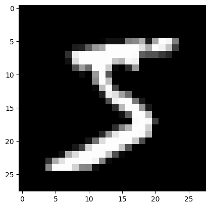

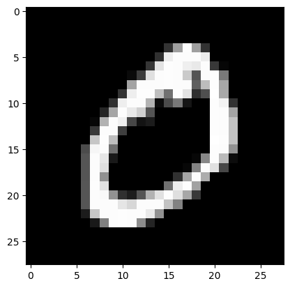

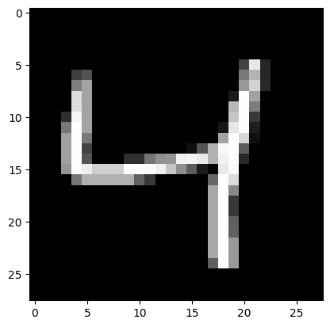

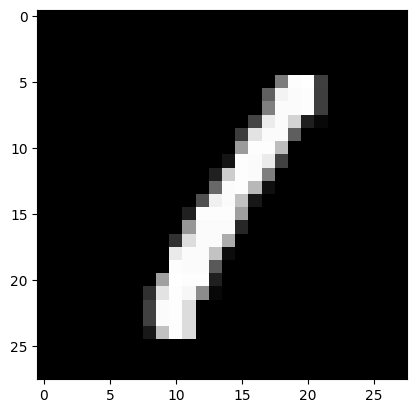

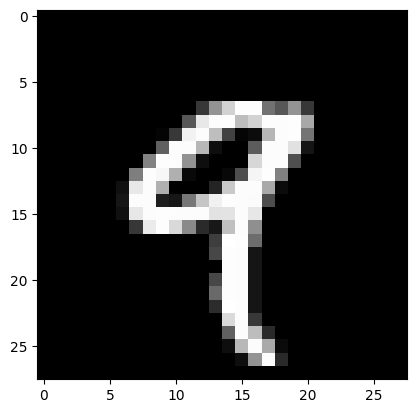

```python
for i in range(5):
  plt.imshow(x_train[i],cmap="gray")
  plt.show()
```

```python
y_train
```

```
array([5, 0, 4, ..., 5, 6, 8], dtype=uint8)
```

```python
x = x_train
y = y_train
```

```python
y_encoded = []

for label in y:
    encoded = np.zeros(10)
    encoded[label] = 1
    y_encoded.append(encoded)
```

```python
y_encoded
```

[output not shown]

[output cut: 946 more lines]

[output not shown]

```python
from sklearn.model_selection import train_test_split

x_train,x_test,y_train,y_test = train_test_split(x,y,test_size=0.3)
```

```python
x_train.shape
```

```
(42000, 28, 28)
```

```python
# reshape our x

# (No.of Images,Width,Height,Channels)

x_train= x_train.reshape(x_train.shape[0],28,28,1)
x_test= x_test.reshape(x_test.shape[0],28,28,1)
```

```python
from keras.models import Sequential
from keras.layers import Conv2D,Dense,Flatten,AveragePooling2D

model = Sequential()
model.add(Conv2D(filters=6,kernel_size=(3,3),activation="tanh",input_shape=(28,28,1)))
model.add(AveragePooling2D(pool_size=(3, 3)))
model.add(Conv2D(filters=12,kernel_size=(3,3),activation="tanh"))
model.add(AveragePooling2D(pool_size=(3, 3)))
model.add(Flatten())
model.add(Dense(50,activation="tanh"))
model.add(Dense(10,activation="softmax"))

print(model.summary())
```

```
Model: "sequential"
```

```
┏━━━━━━━━━━━━━━━━━━━━━━━━━━━━━━━━━┳━━━━━━━━━━━━━━━━━━━━━━━━┳━━━━━━━━━━━━━━━┓
┃ Layer (type)                    ┃ Output Shape           ┃       Param # ┃
┡━━━━━━━━━━━━━━━━━━━━━━━━━━━━━━━━━╇━━━━━━━━━━━━━━━━━━━━━━━━╇━━━━━━━━━━━━━━━┩
│ conv2d (Conv2D)                 │ (None, 26, 26, 6)      │            60 │
├─────────────────────────────────┼────────────────────────┼───────────────┤
│ average_pooling2d               │ (None, 8, 8, 6)        │             0 │
│ (AveragePooling2D)              │                        │               │
├─────────────────────────────────┼────────────────────────┼───────────────┤
│ conv2d_1 (Conv2D)               │ (None, 6, 6, 12)       │           660 │
├─────────────────────────────────┼────────────────────────┼───────────────┤
│ average_pooling2d_1             │ (None, 2, 2, 12)       │             0 │
│ (AveragePooling2D)              │                        │               │
├─────────────────────────────────┼────────────────────────┼───────────────┤
│ flatten (Flatten)               │ (None, 48)             │             0 │
├─────────────────────────────────┼────────────────────────┼───────────────┤
│ dense (Dense)                   │ (None, 50)             │         2,450 │
├─────────────────────────────────┼────────────────────────┼───────────────┤
│ dense_1 (Dense)                 │ (None, 10)             │           510 │
└─────────────────────────────────┴────────────────────────┴───────────────┘
```

```
 Total params: 3,680 (14.38 KB)
```

```
 Trainable params: 3,680 (14.38 KB)
```

```
 Non-trainable params: 0 (0.00 B)
```

```
None
```

```python
# train the model

model.compile(loss="sparse_categorical_crossentropy",metrics=["accuracy"])

model.fit(x_train,y_train,epochs=20)
```

```
1313/1313 ━━━━━━━━━━━━━━━━━━━━ 16s 11ms/step - accuracy: 0.7495 - loss: 0.9179
1313/1313 ━━━━━━━━━━━━━━━━━━━━ 20s 11ms/step - accuracy: 0.9491 - loss: 0.1720
1313/1313 ━━━━━━━━━━━━━━━━━━━━ 14s 11ms/step - accuracy: 0.9594 - loss: 0.1304
1313/1313 ━━━━━━━━━━━━━━━━━━━━ 14s 11ms/step - accuracy: 0.9642 - loss: 0.1132
1313/1313 ━━━━━━━━━━━━━━━━━━━━ 14s 11ms/step - accuracy: 0.9686 - loss: 0.0998
1313/1313 ━━━━━━━━━━━━━━━━━━━━ 15s 11ms/step - accuracy: 0.9711 - loss: 0.0866
1313/1313 ━━━━━━━━━━━━━━━━━━━━ 16s 12ms/step - accuracy: 0.9751 - loss: 0.0804
1313/1313 ━━━━━━━━━━━━━━━━━━━━ 15s 12ms/step - accuracy: 0.9766 - loss: 0.0765
1313/1313 ━━━━━━━━━━━━━━━━━━━━ 14s 11ms/step - accuracy: 0.9793 - loss: 0.0652
1313/1313 ━━━━━━━━━━━━━━━━━━━━ 22s 12ms/step - accuracy: 0.9798 - loss: 0.0651
1313/1313 ━━━━━━━━━━━━━━━━━━━━ 14s 11ms/step - accuracy: 0.9798 - loss: 0.0634
1313/1313 ━━━━━━━━━━━━━━━━━━━━ 14s 11ms/step - accuracy: 0.9817 - loss: 0.0565
1313/1313 ━━━━━━━━━━━━━━━━━━━━ 15s 11ms/step - accuracy: 0.9823 - loss: 0.0545
1313/1313 ━━━━━━━━━━━━━━━━━━━━ 15s 11ms/step - accuracy: 0.9832 - loss: 0.0535
1313/1313 ━━━━━━━━━━━━━━━━━━━━ 18s 14ms/step - accuracy: 0.9821 - loss: 0.0552
1313/1313 ━━━━━━━━━━━━━━━━━━━━ 29s 22ms/step - accuracy: 0.9847 - loss: 0.0504
1313/1313 ━━━━━━━━━━━━━━━━━━━━ 14s 11ms/step - accuracy: 0.9847 - loss: 0.0508
1313/1313 ━━━━━━━━━━━━━━━━━━━━ 14s 11ms/step - accuracy: 0.9850 - loss: 0.0495
1313/1313 ━━━━━━━━━━━━━━━━━━━━ 14s 11ms/step - accuracy: 0.9862 - loss: 0.0455
1313/1313 ━━━━━━━━━━━━━━━━━━━━ 14s 11ms/step - accuracy: 0.9856 - loss: 0.0475
```

```
<keras.src.callbacks.history.History at 0x7eb326217bf0>
```

```python
score = model.evaluate(x_test,y_test)
print(score)
```

```
563/563 ━━━━━━━━━━━━━━━━━━━━ 3s 6ms/step - accuracy: 0.9823 - loss: 0.0579
[0.05407733470201492, 0.9829444289207458]
```

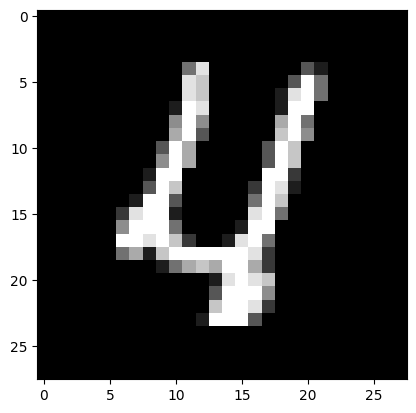

```python
# Running inference

plt.imshow(x_test[100].reshape(28,28),cmap="gray")
plt.show()
```

```python
result = model.predict([x_test[100].reshape(1, 28, 28, 1)])
print(np.argmax(result))
```

```
1/1 ━━━━━━━━━━━━━━━━━━━━ 0s 97ms/step
4
```

```python
from sklearn.datasets import fetch_openml
from sklearn.model_selection import train_test_split, GridSearchCV
from sklearn.preprocessing import StandardScaler
from sklearn.svm import SVC
from sklearn.metrics import accuracy_score
import time

# Load MNIST (only 5000 samples for speed)
X, y = fetch_openml('mnist_784', version=1, return_X_y=True, as_frame=False)
X, y = X[:5000], y[:5000]  # reduce for speed

# Scale features
scaler = StandardScaler()
X_scaled = scaler.fit_transform(X)

# Split data
X_train, X_test, y_train, y_test = train_test_split(X_scaled, y, test_size=0.2, random_state=42)

# Define smaller parameter grid
param_grid = {
    'C': [1, 10],
    'kernel': ['linear', 'rbf']
}

# GridSearchCV
grid = GridSearchCV(SVC(), param_grid, cv=3, verbose=1, n_jobs=1)

# Fit and time
start = time.time()
grid.fit(X_train, y_train)
end = time.time()

# Evaluation
print("Best Parameters:", grid.best_params_)
```

```
Fitting 3 folds for each of 4 candidates, totalling 12 fits
Best Parameters: {'C': 10, 'kernel': 'rbf'}
```

```python
grid.best_params_
```

```
{'C': 10, 'kernel': 'rbf'}
```

```python
y_hap6 = grid.predict(X_test) # make predictions on the test set
y_haper6 = grid.predict(X_train) # make predictions on the test set
```

```python
a1=accuracy_score(y_train,y_haper6)     # Checking accuracy_score # evaluation metrics for classification model
a1
```

```
1.0
```

```python
A1=accuracy_score(y_test,y_hap6)     # Checking accuracy_score # evaluation metrics for classification model
A1
```

```
0.935
```

```python
import tensorflow
from sklearn.ensemble import RandomForestClassifier
from sklearn.model_selection import GridSearchCV
from sklearn.metrics import accuracy_score
from tensorflow.keras.datasets import mnist
import time

# Load and preprocess MNIST data
(x_train, y_train), (x_test, y_test) = mnist.load_data()
x_train = x_train.reshape(-1, 28*28) / 255.0
x_test = x_test.reshape(-1, 28*28) / 255.0

# Optional: reduce for speed
x_train_small = x_train[:5000]
y_train_small = y_train[:5000]

# Define parameter grid
param_grid = {
    'n_estimators': [50, 100],
    'max_depth': [10, 20],
    'criterion': ['gini', 'entropy']
}

# Grid search
rf = RandomForestClassifier(random_state=42)
grid1 = GridSearchCV(rf, param_grid, cv=3, verbose=1, n_jobs=-1)

# Fit
start = time.time()
grid1.fit(x_train_small, y_train_small)
end = time.time()

# Predict on test set
best_model = grid1.best_estimator_
y_pred_test = best_model.predict(x_test)

# Evaluation
print("Best Parameters:", grid1.best_params_)
print("Test Accuracy:", accuracy_score(y_test, y_pred_test))
```

```
Fitting 3 folds for each of 8 candidates, totalling 24 fits
Best Parameters: {'criterion': 'entropy', 'max_depth': 20, 'n_estimators': 100}
Test Accuracy: 0.9367
```

```python
from sklearn.neighbors import KNeighborsClassifier
from sklearn.model_selection import GridSearchCV
from sklearn.metrics import accuracy_score
from tensorflow.keras.datasets import mnist
import time

# Load MNIST data
(x_train, y_train), (x_test, y_test) = mnist.load_data()

# Flatten and normalize
x_train = x_train.reshape(-1, 28*28) / 255.0
x_test = x_test.reshape(-1, 28*28) / 255.0

# Optional: Reduce training size for speed (KNN is slow)
x_train_small = x_train[:5000]
y_train_small = y_train[:5000]

# Define parameter grid
param_grid = {
    'n_neighbors': [3, 5, 7],
    'weights': ['uniform', 'distance'],
    'algorithm': ['auto']
}

# Initialize model and GridSearchCV
knn = KNeighborsClassifier()
grid = GridSearchCV(knn, param_grid, cv=3, verbose=1, n_jobs=-1)

# Fit model
start = time.time()
grid.fit(x_train_small, y_train_small)
end = time.time()

# Best model and prediction
best_model = grid.best_estimator_
y_pred_test = best_model.predict(x_test)

# Evaluation
print("Best Parameters:", grid.best_params_)
print("Test Accuracy:", accuracy_score(y_test, y_pred_test))
```

```
Fitting 3 folds for each of 6 candidates, totalling 18 fits
Best Parameters: {'algorithm': 'auto', 'n_neighbors': 3, 'weights': 'distance'}
Test Accuracy: 0.9379
```

# Model Comparison Report – MNIST Dataset

## Algorithms Used

- Logistic Regression
- K-Nearest Neighbors (KNN)
- Random Forest
- Gradient Boosting
- Support Vector Machine (SVM)
- MLPClassifier

## Best Performing Models

- The following models showed **superior performance** on the MNIST dataset:
  - **Support Vector Machine (SVM)** – Accuracy: **~92%**
  - **MLPClassifier** – Accuracy: **~90%**
  - **K-Nearest Neighbors** – Accuracy: **~90%**
  - **Random Forest** – Accuracy: **~91%**

## Moderate Performing Models

- Models showing **moderate performance**:
  - Logistic Regression – ~86%
  - Gradient Boosting – ~89%

# Final Challenges and Observations

### Data Normalization

- MNIST images have pixel values ranging from **0 to 255**.
- Scaling to **0–1 range** improves model accuracy, especially for algorithms like SVM and KNN.

### Feature Representation

- All 784 pixel features are **numerical** and **flattened** from 28×28 images.
- CNNs can better capture **spatial structure** of images.